# Deviations from Excel defaults

The overall intent of this package is to mimic as completely as possible the output available from the [NHS Making Data Count](https://www.england.nhs.uk/publication/making-data-count/) Excel tools. However, we have identified some areas where the R implementation should deviate from the main Excel tools. We have done this only after careful consideration, and we believe there is a benefit to deviating.

This vignette documents what these differences are, and how to set options to over-ride them, so that if you need to you can completely replicate the output that the Excel tools would create.

You may consider this important if for example you are publishing outputs from both the Excel tool and this R tool, and need the outputs to be completely consistent.

## List of Deviations

### 1. Treatment of outlying points

By default, this package will screen outlying points, removing them from the moving range calculation, and hence from the process limits calculation. This is in line with the published paper:

> Nelson, Lloyd S. (1982) Control Charts for Individual Measurements, *Journal of Quality Technology* 14(3): 172-173

It is discussed further in the book:

> Provost, Lloyd P. & Murray, Sandra K. (2011) *The Health Care Data Guide: Learning from Data for Improvement*, San Francisco, CA: Jossey-Bass, pp.155, 192

The “Making Data Count” Excel tools do not screen outlying points, and all points are included in the moving range and limits calculations. If outlying points exist, the process limits on the Excel tools will therefore be wider than if outlying points were screened from the calculation.

This behaviour is controlled by the `screen_outliers` argument. By default, `screen_outliers = TRUE`.

To replicate the Excel method, set the argument `screen_outliers = FALSE`.

The two charts below demonstrate the default, and how to over-ride to replicate the Excel tools.

#### R Package Default:

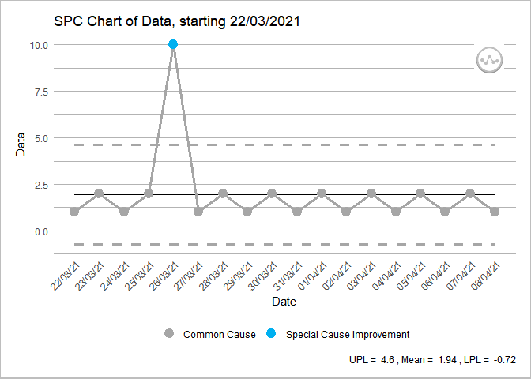

```r
data <- c(1, 2, 1, 2, 10, 1, 2, 1, 2, 1, 2, 1, 2, 1, 2, 1, 2, 1)
date <- seq(as.Date("2021-03-22"), by = 1, length.out = 18)
df <- tibble::tibble(data, date)

# screen_outliers = TRUE by default
spc_data <- ptd_spc(df, value_field = data, date_field = date)
spc_data %>%
  plot() +
  labs(
    caption = paste(
      "UPL = ", round(spc_data$upl[1], 2),
      ", Mean = ", round(spc_data$mean_col[1], 2),
      ", LPL = ", round(spc_data$lpl[1], 2)
    )
  )
```

#### Over-riding to replicate “Making Data Count” Excel output:

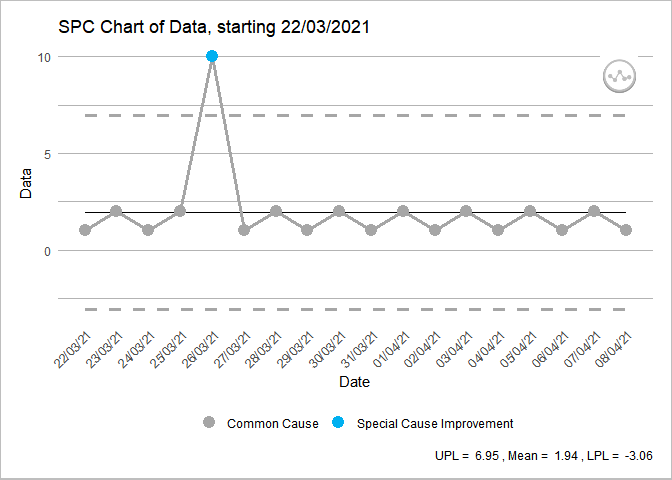

```r
# setting screen_outliers = FALSE produces the same output as Excel
spc_data <- ptd_spc(df, value_field = data, date_field = date, screen_outliers = FALSE)
spc_data %>%
  plot() +
  labs(
    caption = paste(
      "UPL = ", round(spc_data$upl[1], 2),
      ", Mean = ", round(spc_data$mean_col[1], 2),
      ", LPL = ", round(spc_data$lpl[1], 2)
    )
  )
```

### 2. Breaking of lines

By default, this package will break process and limit lines when a plot is rebased. The Excel tool draws all lines as continuous lines. However, rebasing is a change to the process, so by breaking lines it more clearly indicates that a change in process has happened.

This can be controlled with the `break_lines` argument. There are 4 possible values:

- “both” (default)
- “limit” (to just break the limit lines, but leave the process line connected)
- “process” (to just break the process line, but leave the limit lines connected)
- “none” (as per the Excel tool).

Examples of these 4 are shown below:

#### R Package Default:

```r
spc_data <- ae_attendances %>%
  group_by(period) %>%
  summarise(across(attendances, sum)) %>%
  ptd_spc(attendances, period, rebase = as.Date(c("2017-04-01", "2018-04-01")))
```

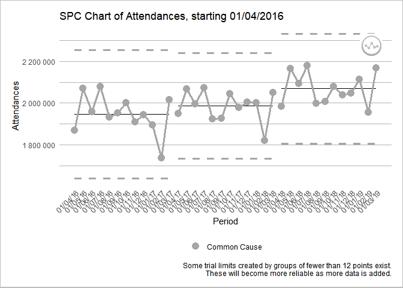

```r
plot(spc_data, break_lines = "both")
```

#### Just breaking the limit lines:

[figure not shown]

```r
plot(spc_data, break_lines = "limits")
```

#### Just breaking the process line:

[figure not shown]

```r
plot(spc_data, break_lines = "process")
```

#### Over-riding to replicate “Making Data Count” Excel output:

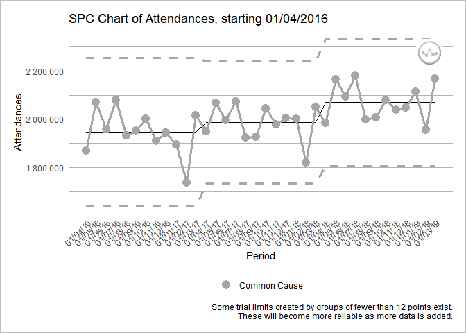

```r
plot(spc_data, break_lines = "none")
```

### 3. X Axis Text Angle

As can be seen in the plots above, by default this package will print x axis text rotated by 45 degrees for better utilisation of space, and readability. Excel’s behaviour is to print this text at 90 degrees to the axis.

Text angle can be over-ridden by passing a ggplot `theme()` into the `theme_override` argument of the plot function. Any of the modifications documented in the [ggplot2 theme documentation](https://ggplot2.tidyverse.org/reference/theme.html) can be made, but in this case we just need to modify `axis.text.x`.

#### To re-instate 90 degree axis text:

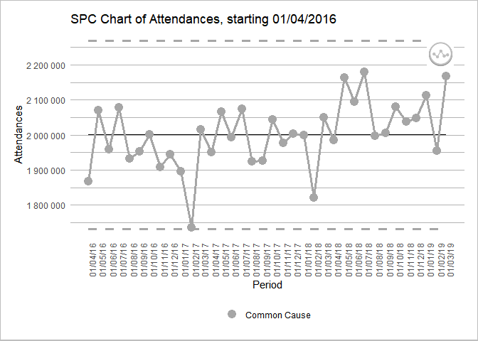

```r
ae_attendances %>%
  group_by(period) %>%
  summarise(across(attendances, sum)) %>%
  ptd_spc(attendances, period) %>%
  plot(theme_override = theme(axis.text.x = element_text(angle = 90)))
```

Find the package code on [GitHub](https://github.com/nhs-r-community/NHSRplotthedots).